# R Fundamentals Part4-6: what is R markdown?

D-Lab

March 25, 2019

# 1 R Markdown

# 2 Why use R Markdown?

R Markdown allows you create documents of various kinds. Check out the [R Markdown Quick Tour](http://rmarkdown.rstudio.com/authoring_quick_tour.html). Some highlights:

1. Enter text as normal. No special formatting is required for regular text.
2. Code should be entered inside “chunks” that look like this:

```r
2 + 2 # hashtag text within a chunk to comment it.
```

```
## [1] 4
```

```r
# click "Code" and "Insert chunk" to see the keyboard shortcut.

data(iris); summary(iris)
```

```
##   Sepal.Length    Sepal.Width     Petal.Length    Petal.Width
##  Min.   :4.300   Min.   :2.000   Min.   :1.000   Min.   :0.100
##  1st Qu.:5.100   1st Qu.:2.800   1st Qu.:1.600   1st Qu.:0.300
##  Median :5.800   Median :3.000   Median :4.350   Median :1.300
##  Mean   :5.843   Mean   :3.057   Mean   :3.758   Mean   :1.199
##  3rd Qu.:6.400   3rd Qu.:3.300   3rd Qu.:5.100   3rd Qu.:1.800
##  Max.   :7.900   Max.   :4.400   Max.   :6.900   Max.   :2.500
##        Species
##  setosa    :50
##  versicolor:50
##  virginica :50
##
##
##
```

3. Run a line of code like normal - remember you can select multiple lines to run at once.
4. Click the green “Play” button on the right side of a chunk to run the entire chunk.
5. Click the “Run” button (top right portion of your R Markdown window) to see various run options.
6. Click “Tools” –> “Global options” –> “Code” and make sure the box is checked that says “soft wrap R source files”.
7. Click “Tools” –> “Global options” –> “Appearance” to change your color and font settings.
8. Click “Tools” –> “Global options” –> “R Markdown” and make sure to uncheck the box “Show output inline for all R Markdown documents” *and* check the box that says “Show document outline by default”. Also click “Code” –> “Show document outline” to include a clickable table of contents in your RStudio session.
9. Use “knitr” to generate [.HTML](https://html.com/), .docx, .pdf files, slideshows, and fancy applications. Click [here](https://rmarkdown.rstudio.com/) and [here](https://bookdown.org/yihui/rmarkdown/) for walkthroughs and examples.

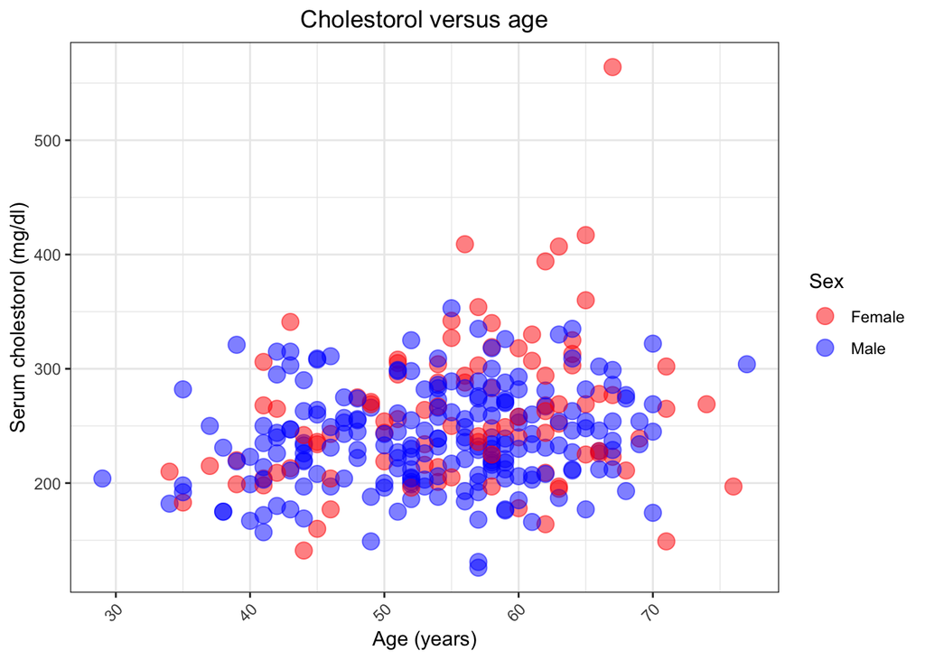

```r
heart = read.csv("/Users/evan.admin/Desktop/R-Fundamentals/data-raw/heart.csv")

# For sex column, recode 0 = Female, 1 = Male
heart$sex_fac = ifelse(heart$sex == 0, "Female", "Male")

library(ggplot2)
ggplot(data = heart, aes(x = age, y = chol, col = sex_fac)) +
  geom_point(size = 4, alpha = 0.5) +
  ggtitle("Cholestorol versus age") +
  xlab("Age (years)") +
  ylab("Serum cholestorol (mg/dl)") +
  labs(col = "Sex") +
  scale_color_manual(values = c("red", "blue")) +
  theme_bw() +
  theme(plot.title = element_text(hjust = 0.5)) +
  theme(axis.text.x = element_text(angle = 45, hjust = 1))
```

11. Include statistical tests as well:

```r
cor.test(heart$age, heart$chol)
```

```
##
##  Pearson's product-moment correlation
##
## data:  heart$age and heart$chol
## t = 3.7948, df = 301, p-value = 0.0001786
## alternative hypothesis: true correlation is not equal to 0
## 95 percent confidence interval:
##  0.1034917 0.3186831
## sample estimates:
##      cor
## 0.213678
```

Be sure to [check out the RStudio cheatsheet](https://www.rstudio.com/resources/cheatsheets/#rmarkdown) to learn how to format text, tables, lists, and much more!

# 3 Hidden code